# STAT340 Discussion 2: Conditional Probability

## XKCD comic

[figure not shown]

In this lab we’ll explore some fun and weird paradoxes and fallacies related to conditional probability.

### 1. Berkson’s Paradox : Attractive people have worse personalities?

Are attractive people more likely to be jerks? This is an observation some people make - it seems when going on a date with someone the more attractive they are the worse their personality seems to be. Why could this possibly be?

This can be explained using conditional probability. Suppose that in the population people’s personalities are uniformly distributed between 1 and 10, same goes for attractiveness.

```r
#Build the population
pop.size <- 100000

#The ceiling function rounds up. Taking a uniform from 0 to 10 and rounding up will give us an integer from 1 to 10
attractiveness <- ceiling(runif(pop.size,0,10))
personality <- ceiling(runif(pop.size,0,10))
dating.population <- data.frame(attractiveness,personality)
```

1. What is the correlation between attractiveness and personality in the population? You can use the cor function in R to calculate correlation.

```r
corre <- cor(attractiveness, personality)
corre
```

```
## [1] 0.003205823
```

2. Let’s imagine a new dating app called “Datem” (get it?). The population using the app is representative of the overall population. When you view someone’s profile you make some judgement about their personality as well as their attractiveness. Suppose you will only swipe right if the sum of their attractiveness and personality is at least 10.

Go through the population and create a subset who get a right swipe. You can use the subset(df, condition) function to do this easily in R. After you do, check the correlation between attractiveness and personality.

```r
# Create subset
right_swipe_population <- subset(dating.population, attractiveness + personality >= 10)

# Correlation between attractiveness and personality in the subset
correlation_right_swipe <- cor(right_swipe_population$attractiveness, right_swipe_population$personality)

correlation_right_swipe
```

```
## [1] -0.4592604
```

3. Consider other standards (higher and lower) for the sum of these two traits. What is the correlation in the subset for others. Bonus: You could create a vector standard <- 2:19 and for each standard calculate the correlation, then plot the two variables to see the effect of someone’s “Swipe Right” standard on the people they potentially get matched with.

```r
# Lower: greater than equal to 5 swipe
five_swipe_population <- subset(dating.population, attractiveness + personality >= 5)
# Correlation between attractiveness and personality in the subset
correlation_right_swipe <- cor(five_swipe_population$attractiveness, five_swipe_population$personality)
correlation_right_swipe
```

```
## [1] -0.1256491
```

```r
# Upper: greater than equal to 15 swipe
fifteen_swipe_population <- subset(dating.population, attractiveness + personality >= 15)
# Correlation between attractiveness and personality in the subset
correlation_right_swipe <- cor(fifteen_swipe_population$attractiveness, fifteen_swipe_population$personality)
correlation_right_swipe
```

```
## [1] -0.4998617
```

4. Big question: If it seems that when dating that attractive people tend to be jerks, is there another explanation for this?

When we set this constraint, we are basically “diagonally cutting” the distribution such that it inherently has a negative correlation.

### 2. The Book Award

Researchers have found that quality ratings for books that had won literary awards went down after the book won the award. This seems paradoxical, since people usually like books more if they know other people like them.

Imagine an author who has a cult following. Fans of this author love their books in general. A new book is published and the ratings received from fans can be modeled with a binomial(5,.9) random variable. When someone from the general public reads the book they give it a rating from a binomial(5,.5) distribution.

1. Suppose that for the first 5 months that 90% of the ratings come from fans of the author and only 10% come from people in the general public. What would the average star rating on Amazon be?

```r
# Expected value for Binomial is n * p

# Expected ratings for fans and general public
E_fans <- 5 * 0.9
E_general_public <- 5 * 0.5

# Overall average star rating before the award
average_before_award <- (0.9 * E_fans) + (0.1 * E_general_public)
average_before_award
```

```
## [1] 4.3
```

```r
# Overall average star rating after the award
average_after_award <- (0.8 * E_fans) + (0.2 * E_general_public)
average_after_award
```

```
## [1] 4.1
```

### 3. Mediocre State University

Not everybody gets into the best college. That’s just the way it is. For those who can’t get into the best university there’s Mediocre State University (MSU). Their motto: “You take the best, we’ll take the rest.”

AS the first years are getting to know each other they discover a weird trend; those who got high GPAs in high school tended to have low SAT scores, and vice versa. How could this be the case?

Let’s simplify the college application process and imagine that schools just look at two factors: a student’s GPA and a student’s SAT score.

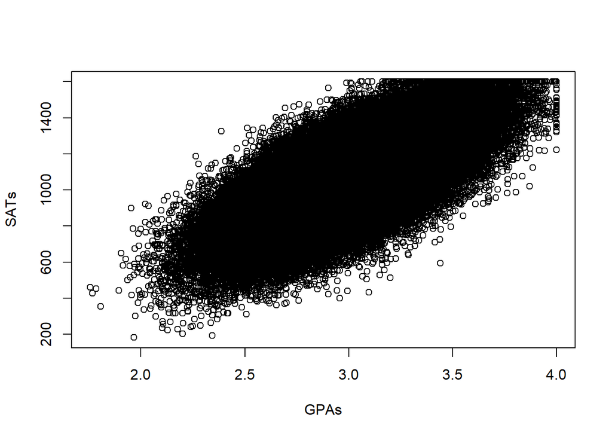

```r
# Build a population of high school seniors applying for college.
pop.size <- 100000
GPAs <- rnorm(pop.size, 3,.3)
GPAs <- pmin(GPAs, 4)
GPAS <- pmax(GPAs,0)
SATs <- 1050+500*(GPAs-3)+rnorm(pop.size,0,150)
SATs <- pmin(SATs,1600)
SATs <- pmax(SATs,0)
seniors <- data.frame(GPAs, SATs)
plot(GPAs,SATs)
```

a. What is the correlation between GPA and SAT score in the population of high school seniors?

```r
  # TODO: code goes here.
gpa_sat_cor <- cor(GPAs, SATs)
gpa_sat_cor
```

```
## [1] 0.7090165
```

2. Do you remember what a z-score is? Given a set of data, the z-score of a value is a standardized value. Standardization is done by subtracting the sample mean and dividing by the sample standard deviation. Don’t forget parentheses around the numerator.

$$z = \frac{x-\bar{x}}{s}$$

```r
#Create a vector called zGPAs where you standardize the GPA scores into z-scores
mean_GPA <-  mean(GPAs)
sd_GPA <- sd(GPAs)
zGPAs <- (GPAs - mean_GPA) / sd_GPA

# Create another vector called zSATs where you standardize the SAT scores into z-scores
mean_SAT <- mean(SATs)
sd_SAT <- sd(SATs)
zSATs <- (SATs - mean_SAT) / sd_SAT
```

3. Mediocre State University does not have the highest standards for acceptance. As long as the average z-score for GPA and SAT are above 0 a person is accepted.

However there’s another school that students really want to go into: Exceptional State University. Their acceptance standards are higher. A the average of an applicant’s GPA and SAT z score needs to be at least 1 to be accepted to ESU.

Anybody who is accepted to ESU will go there. Anybody who is not accepted to ESU but is accepted to MSU will go to MSU. Create a subset of the population to reflect the entering class of first years.

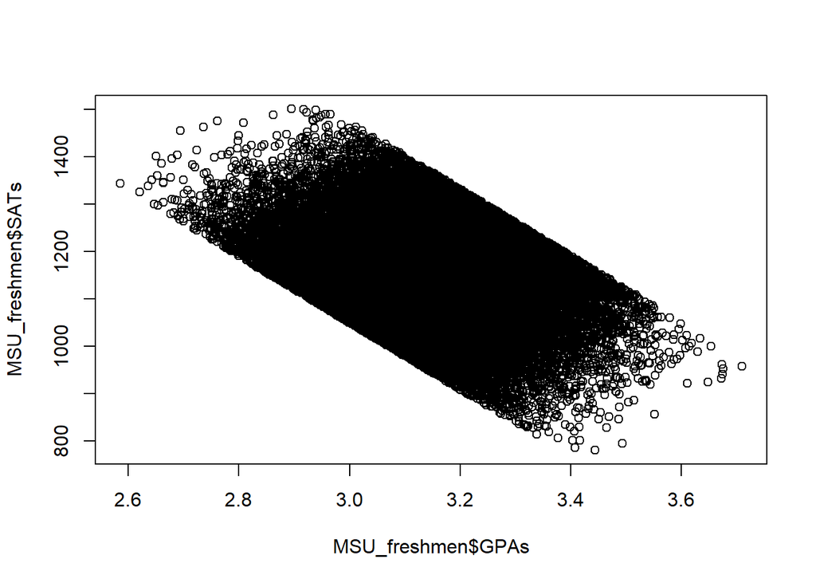

```r
# Create a subset of the population who are accepted to MSU and not accepted to ESU. This represents the freshman class of 2027.
avg_zscore <- (zGPAs + zSATs) / 2


# Accepted to MSU: avg_zscore >= 0
# Not accepted to ESU: avg_zscore < 1
MSU_freshmen <- subset(seniors, avg_zscore >= 0 & avg_zscore < 1)

plot(MSU_freshmen$GPAs, MSU_freshmen$SATs)
```

4. What is the correlation between GPA and SAT score among undergrade attending MSU?

```r
msu_gpa_sat_cor <- cor(MSU_freshmen$GPAs, MSU_freshmen$SATs)

msu_gpa_sat_cor
```

```
## [1] -0.2979779
```

5. Can you now address the original question: Why is it that students at MSU who had high SAT scores tend to have low GPA scores?

ESU has students generally have high GPAs AND high SATs, which effectively “cuts off” the top right portion of the data. What is left is data that has a negative correlation, meaning students at MSU who had high SAT scores tend to have low GPA scores.

### 4. Base Rate Fallacy

Suppose that we are living through a pandemic. Imagine that the hospitalization rate for those infected is 10% (if a person is infected, there’s a 10% chance that they end up in the hospital). A vaccine is developed and if a person is vaccinated then their hospitalization rate drops to 0.5%.

1. Early on only 5% of the population is vaccinated. What proportion of those hospitalized are vaccinated?

```r
#Your code / calculations go here

# Given values
P_V <- 0.05  # Probability of being vaccinated
P_U <- 1 - P_V  # Probability of being unvaccinated
P_H_given_V <- 0.005  # Hospitalization rate for vaccinated
P_H_given_U <- 0.10  # Hospitalization rate for unvaccinated

P_V_given_H <- (P_H_given_V * P_V) / ((P_H_given_V * P_V) + (P_H_given_U * P_U))

P_V_given_H
```

```
## [1] 0.002624672
```

2. Later on in the pandemic 25% of the population is vaccinated. What proportion of those hospitalized are vaccinated?

```r
#Your code / calculations go here

# New proportions
P_V <- 0.25  # Probability of being vaccinated
P_U <- 1 - P_V  # Probability of being unvaccinated

P_V_given_H <- (P_H_given_V * P_V) / ((P_H_given_V * P_V) + (P_H_given_U * P_U))

P_V_given_H
```

```
## [1] 0.01639344
```

3. Later on 90% of the population is vaccinated. What proportion of those hospitalized are vaccinated?

```r
#Your code / calculations go here

# New proportions
P_V <- 0.9  # Probability of being vaccinated
P_U <- 1 - P_V  # Probability of being unvaccinated

P_V_given_H <- (P_H_given_V * P_V) / ((P_H_given_V * P_V) + (P_H_given_U * P_U))

P_V_given_H
```

```
## [1] 0.3103448
```

4. You hear someone on the news saying that the proportion of those vaccinated in the hospital is rising and rising, and that this is evidence that the efficacy of the vaccine is diminishing. Do you agree with this argument, or is there an other explanation?

No, this exemplifies the “Base Rate Fallacy”, as the number of those vaccinated in the population increasing will inherently cause the proportion of those vaccinated in the hospital to also increase.